# LSCA Individual Assignment

#### Q4. Final Forecast (using the optimal model amongst all the models)

The model selections from the previous parts conclude that:

- **Store 46673** (California, Ninth Street) will use the **Holt-Winter model: ETS(A,N,A)**
- **Store 4904** (California, Shattuck Sq) will use the **Holt-Winter model: ETS(A,N,A)**
- **Store 12631** (New York, Myrtle Avenue) will use the **ARIMA model: ARIMA(0,1,1)(0,1,1)[7]**
- **Store 20974** (New York, Whitney Avenue) will use the **ARIMA model: ARIMA(1,0,1)(2,1,0)[7]**

The forecast is created for each store, and can be seen in each of the store’s plot.

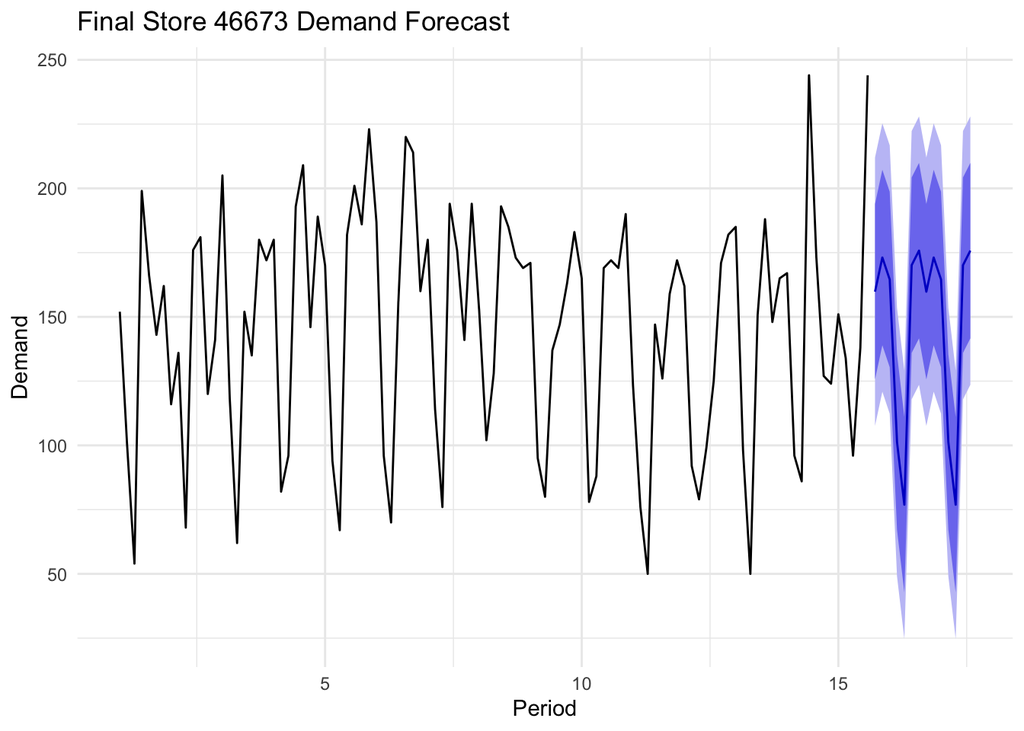

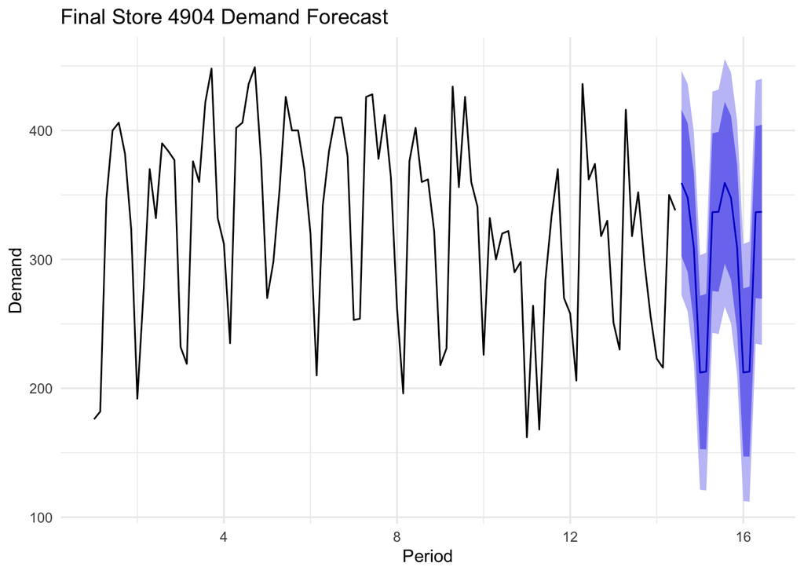

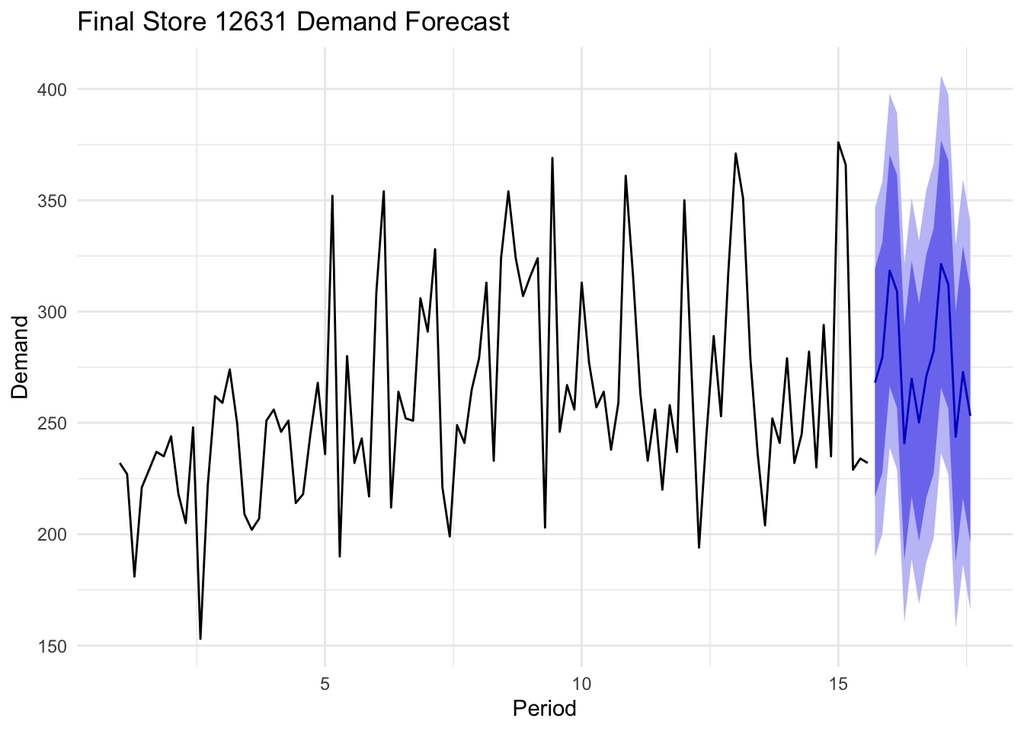

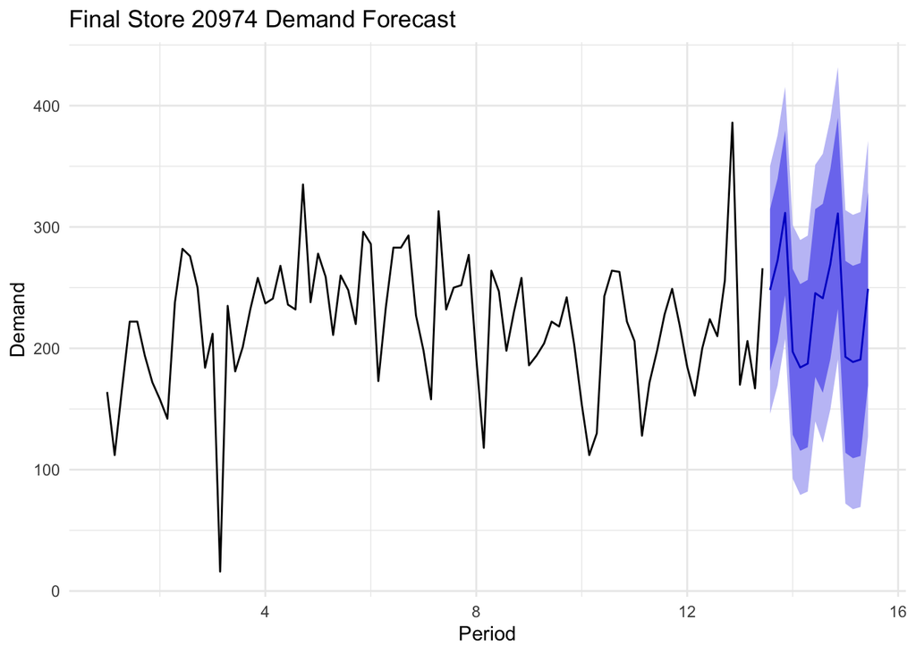

```
##          date store_46673..ounces. store_4904..ounces. store_12631..ounces.
## 1  2025-06-16                  160                 359                  268
## 2  2025-06-17                  173                 348                  279
## 3  2025-06-18                  165                 309                  318
## 4  2025-06-19                  101                 212                  309
## 5  2025-06-20                   77                 213                  241
## 6  2025-06-21                  170                 337                  270
## 7  2025-06-22                  176                 337                  250
## 8  2025-06-23                  160                 359                  271
## 9  2025-06-24                  173                 348                  282
## 10 2025-06-25                  165                 309                  321
## 11 2025-06-26                  101                 212                  312
## 12 2025-06-27                   77                 213                  244
## 13 2025-06-28                  170                 337                  273
## 14 2025-06-29                  176                 337                  253
##    store_20974..ounces.
## 1                   248
## 2                   273
## 3                   312
## 4                   197
## 5                   184
## 6                   187
## 7                   246
## 8                   241
## 9                   269
## 10                  311
## 11                  193
## 12                  189
## 13                  191
## 14                  249
```